# 02_security_power_analyses

Dallas Novakowski

15/11/2021

After the pretest, we found substantial variation within conditions. From data vizualization, a few strategies can be identified for guiding consumption of security goods: firstly, purchasing none at all (the most risk-accepting strategy), secondly, purchasing the maximum possible, and third, purchasing the median value of the possible range. Lastly, for those that do not use one of these max/min/median strategies, participants seem to make purchases in multiples of five.

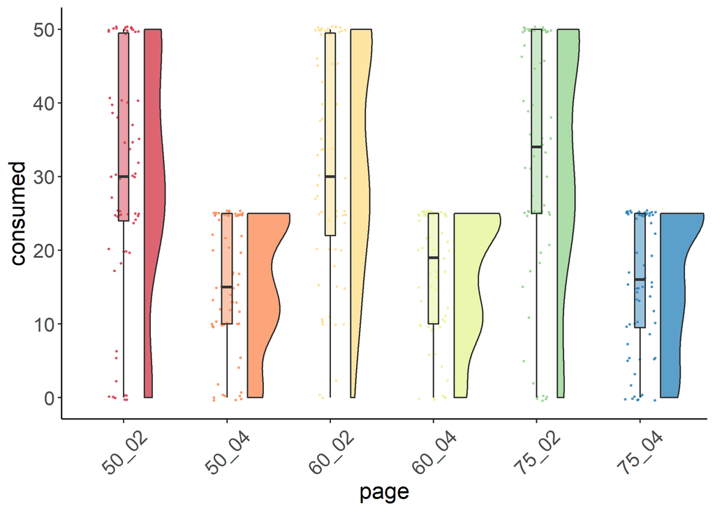

For this project, we will be using values from the 50_02 condition, which corresponds to a baseline 50% chance of successful thefts, and each unit of security costing $0.02. This condition seems to produce the least skewed data, at -0.47.

The following document details power analyses using R package Superpower conducted to find adequately-powered sample sizes at varying effect sizes.

A major benefit of having run a pilot study is getting information on mean and standard deviation for our variables. It is generally uninformative to conduct a power analysis without these values, particularly the sd. Here, we can use a baseline average security consumption of 30.57 units , with a standard deviation of 16.18.

# Trial 1: partial η2 = .05

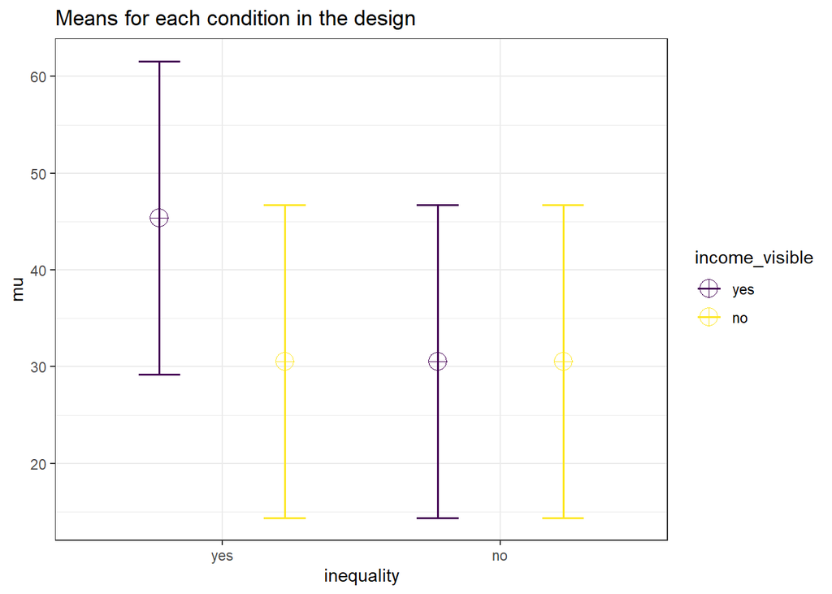

```r
nsims <- 2000

# detecting .05 partial η2, with 95% power
security_05_design <- ANOVA_design(design = "2b*2b",
                   n = 63,
                   mu = c(45.4, base_mean, base_mean, base_mean),
                   sd = base_sd,
                   # r = 0.8,
                   labelnames = c("inequality", "yes", "no", "income_visible", "yes", "no"),
                   plot = TRUE)
```

It is worth noting that this design constitutes a [“no-way” interaction,](https://aaroncaldwell.us/SuperpowerBook/the-no-way-interactions.html) which “requires at least twice as many subjects per cell as a study that simply aims to show the simple effect.” This requirement follows [“because we are testing the reduction of that same effect”](http://datacolada.org/17).

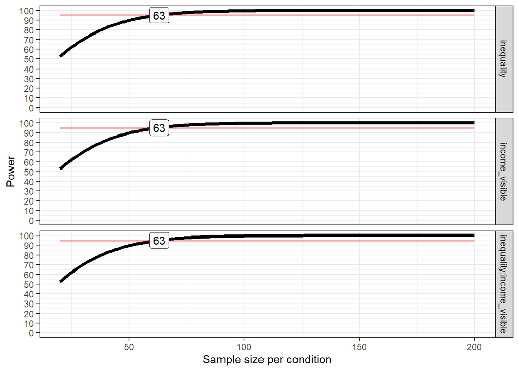

> According to Cohen’s (1988) guidelines, f2≥ 0.02, f2≥ 0.15, and f2 ≥ 0.35 represent small, medium, and large effect sizes, respectively.

> for eta square Basic rules of thumb are that: η2 = 0.01, indicates small effect; η2 = 0.06, medium effect; η2 = 0.14 large effect.

|  | power | partial_eta_squared | cohen_f | non_centrality |
| --- | --- | --- | --- | --- |
| inequality | 95.19528 | 0.0506681 | 0.2310246 | 13.23635 |
| income_visible | 95.19528 | 0.0506681 | 0.2310246 | 13.23635 |
| inequality:income_visible | 95.19528 | 0.0506681 | 0.2310246 | 13.23635 |

Also following from the no-way interaction, each coefficient has the same effect size.

# Trial 2: partial η2 = .01

```r
# detecting .01 partial η2, with 95% power
security_01_design <- ANOVA_design(design = "2b*2b",
                   n = 320,
                   mu = c(37.1, base_mean, base_mean, base_mean),
                   sd = base_sd,
                   # r = 0.8,
                   labelnames = c("inequality", "yes", "no", "income_visible", "yes", "no"))
```

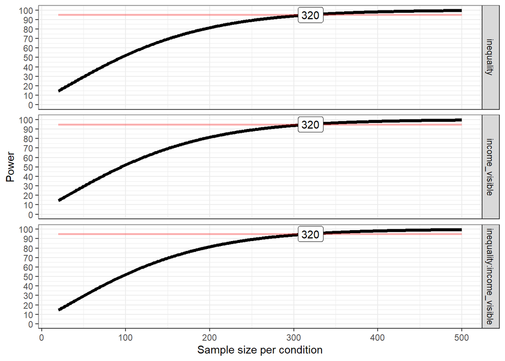

|  | power | partial_eta_squared | cohen_f | non_centrality |
| --- | --- | --- | --- | --- |
| inequality | 95.03893 | 0.0101173 | 0.1010976 | 13.04165 |
| income_visible | 95.03893 | 0.0101173 | 0.1010976 | 13.04165 |
| inequality:income_visible | 95.03893 | 0.0101173 | 0.1010976 | 13.04165 |

# Trial 3: partial η2 = .02

```r
# detecting .01 partial η2, with 95% power
security_02_design <- ANOVA_design(design = "2b*2b",
                   n = 161,
                   mu = c(39.8, base_mean, base_mean, base_mean),
                   sd = base_sd,
                   # r = 0.8,
                   labelnames = c("inequality", "yes", "no", "income_visible", "yes", "no"))
```

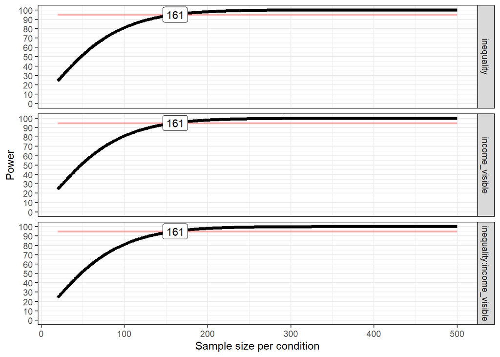

|  | power | partial_eta_squared | cohen_f | non_centrality |
| --- | --- | --- | --- | --- |
| inequality | 95.10216 | 0.0200674 | 0.1431026 | 13.10616 |
| income_visible | 95.10216 | 0.0200674 | 0.1431026 | 13.10616 |
| inequality:income_visible | 95.10216 | 0.0200674 | 0.1431026 | 13.10616 |